# Survival Analysis: Cox Proportional-Hazards Model

Samuel Moijueh

2019-02-28

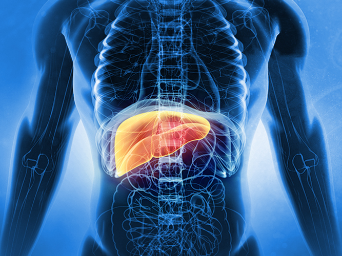

[figure not shown]

# Introduction

The Notebook is divided into tabbed sections as seen below.

## Purpose

Survival analysis is used to study the **time** until some **event** of interest (often referred to as death) occurs.

In this post we will perform a survival analysis on the Primary Biliary Cirrhosis (PBC) Dataset. PBC is a well-known dataset that can be found in [Appendix D](https://onlinelibrary.wiley.com/doi/pdf/10.1002/9781118150672.app4) of [Fleming and Harrington’s book (1991)](https://www.amazon.com/Counting-Processes-Survival-Analysis-Fleming/dp/0471769886) on survival analysis. The dataset is also available to download at NCSU Stats Data [Repository](https://www4.stat.ncsu.edu/~boos/var.select/pbc.html).

**PBC** is an autoimmune disease that causes progressive destruction of the bile ducts. If left untreated, the disease can be fatal.

The data itself is from a **Mayo Clinic** clinical study of a total of 424 PBC patients. The patients were observed over a period of 10 years (1974-1984).

The first cohort of PBC patients were treated with D-penicillamine. The second cohort were treated with a placebo.

In this post, we will answer the following research questions:

1. Are there differences in survival between the two groups of patients? If so, is the difference statistically significant?
2. What clinical characteristics impact a patient’s survival time? Click on the adjacent tab for the list of covariates.
3. Can we make any conclusions regarding the efficacy of D-penicillamine (the experimental drug) on the sample population? Is the effect of the drug on survival time statistically significant? Is the drug one step closer to being ready for market?

Answers to these research questions will appear in green checkboxes

## The Primary Biliary Cirrhosis (PBC) Dataset

The patient’s `status` reveals if they are censored or not. Missing data items are denoted by “.”.

| Variable | Description |
| --- | --- |
| id | case number |
| futime | number of days between treatment and death |
| status | 0=alive, 1=liver transplant, 2=death |
| drug | 1= D-penicillamine, 2=placebo |
| age | age in days |
| sex | 0=male, 1=female |
| ascites | presence of ascites: 0=no 1=yes |
| hepato | presence of hepatomegaly 0=no 1=yes |
| spiders | presence of spiders 0=no 1=yes |
| edema | presence of edema 0=no edema and no diuretic therapy for edema; .5 = edema present without diuretics, or edema resolved by diuretics; 1 = edema despite diuretic therapy |
| bili | serum bilirubin in mg/dl |
| chol | serum cholesterol in mg/dl |
| albumin | albumin in gm/dl |
| copper | urine copper in ug/day |
| alk_phos | alkaline phosphatase in U/liter |
| sgot | SGOT in U/ml |
| trig | triglicerides in mg/dl platelet = platelets per cubic ml/1000 |
| protime | prothrombin time in seconds |
| stage | histologic stage of disease |

## What is Survival Analysis?

Survival Analysis is a statisical approach used to investigate the **time** it takes for an **event** of interest to occur and its relationship with covariates.

Survival analysis is traditionally used to measure the lifetime of populations. However, the event could be anything of interest.

**Survival analysis** is used in a variety of fields such as:

- Actuarial Science and Insurance Industry
  - They analyze life tables, look at probabilities, and assess risk to estimate **durations** such as how long before a person has an accident, how long before a person gets sick, how long before a person dies, etc. Actuaries use this information to help businesses calculate costs, determine premiums for policyholders, develop policies that minimize the cost of risk and uncertainty, etc.
- Medical and Pharmaceutical Industry
  - What is the expected lifetime of patients given treatment A vs patients given treatment B? Is a drug’s efficiacy in the population statistically significant? What is the impact of certain clinical characteristics on a patient’s survival? What is the probability that an individual survives 3 years? Are there differences in survival between groups of patients?
- Engineering
  - Used in reliability theory. How long before failure in a mechnical system and/or device?
- Tech and Digital Marketing Industry
  - What is the time between signup and first order/use? When will a customer churn? When will a store run out of product? How long before a person replaces his/her phone?

The duration of time leading up to the event of interest is called the **survival time**.

# Set up Environment

[figure not shown]

Load packages and import data.

```r
# load required packages
library(pacman)
pacman::p_load(survival, survminer, dplyr, ggplot2, gridExtra, DT, corrplot, broom)

# import PBC dataset, encode missing values as 'NA'
d <- read.table(file = "https://www4.stat.ncsu.edu/~boos/var.select/pbc.dat.txt",
                       na.strings = c('.', 'NA'))

# set column names
colnames(d) <- c('id','futime','status','drug','age','sex','ascites',
                        'hepato','spiders','edema','bili','chol','albumin',
                        'copper','alk_phos','sgot','trig','platelet',
                        'protime','stage')

# convert the time in days to years for simplicity
d$age = floor(d$age / 365)

# remove all rows with missing values from the dataframe
d <- d[complete.cases(d), ]
```

```r
# look at the data
datatable(d, options = list(pageLength = 5))
```

|  | id | futime | status | drug | age | sex | ascites | hepato | spiders | edema | bili | chol | albumin | copper | alk_phos | sgot | trig | platelet | protime | stage |
| --- | --- | --- | --- | --- | --- | --- | --- | --- | --- | --- | --- | --- | --- | --- | --- | --- | --- | --- | --- | --- |
| 1 | 1 | 400 | 2 | 1 | 58 | 1 | 1 | 1 | 1 | 1 | 14.5 | 261 | 2.6 | 156 | 1718 | 137.95 | 172 | 190 | 12.2 | 4 |
| 2 | 2 | 4500 | 0 | 1 | 56 | 1 | 0 | 1 | 1 | 0 | 1.1 | 302 | 4.14 | 54 | 7394.8 | 113.52 | 88 | 221 | 10.6 | 3 |
| 3 | 3 | 1012 | 2 | 1 | 70 | 0 | 0 | 0 | 0 | 0.5 | 1.4 | 176 | 3.48 | 210 | 516 | 96.1 | 55 | 151 | 12 | 4 |
| 4 | 4 | 1925 | 2 | 1 | 54 | 1 | 0 | 1 | 1 | 0.5 | 1.8 | 244 | 2.54 | 64 | 6121.8 | 60.63 | 92 | 183 | 10.3 | 4 |
| 5 | 5 | 1504 | 1 | 2 | 38 | 1 | 0 | 1 | 1 | 0 | 3.4 | 279 | 3.53 | 143 | 671 | 113.15 | 72 | 136 | 10.9 | 3 |
| 7 | 7 | 1832 | 0 | 2 | 55 | 1 | 0 | 1 | 0 | 0 | 1 | 322 | 4.09 | 52 | 824 | 60.45 | 213 | 204 | 9.7 | 3 |
| 8 | 8 | 2466 | 2 | 2 | 53 | 1 | 0 | 0 | 0 | 0 | 0.3 | 280 | 4 | 52 | 4651.2 | 28.38 | 189 | 373 | 11 | 3 |
| 9 | 9 | 2400 | 2 | 1 | 42 | 1 | 0 | 0 | 1 | 0 | 3.2 | 562 | 3.08 | 79 | 2276 | 144.15 | 88 | 251 | 11 | 2 |
| 10 | 10 | 51 | 2 | 2 | 70 | 1 | 1 | 0 | 1 | 1 | 12.6 | 200 | 2.74 | 140 | 918 | 147.25 | 143 | 302 | 11.5 | 4 |
| 11 | 11 | 3762 | 2 | 2 | 53 | 1 | 0 | 1 | 1 | 0 | 1.4 | 259 | 4.16 | 46 | 1104 | 79.05 | 79 | 258 | 12 | 4 |

[output cut: 266 more lines]

The primary response variable is `futime`. This is the number of days between the patient receiving drug treatment and occurrence of death, receiving a liver transplant, or the end of the 10 year study observation period.

Patients who alive are denoted by `status=0`. Patients who became *censored* due to receiving a liver transplant are denoted by `status=1`. Patients who died to PBC disease are denoted by `status=2`.

The `Survival` library requires that the event of interest have a `status=1` and the censored events to have a `status=0`. Alive and liver transplant are both censored events. We will make this conversion now.

```r
# recode status
d$status = ifelse(d$status == 2, 1, 0)
table(d$status)/length(d$status)
```

```
##
##         0         1
## 0.5978261 0.4021739
```

A percent calculation of the status shows that approximately 40% of patients died during the observation period.

# Visually Explore the Data

Click on the tabs for different aspects of the Exploratory Data Analysis.

## Histogram of Age Variable

The ages of PCB patients are normally distributed. The median age is approximately 49 years. Patients range from ages 26 to 78. Click on the next tab for the correlation matrix.

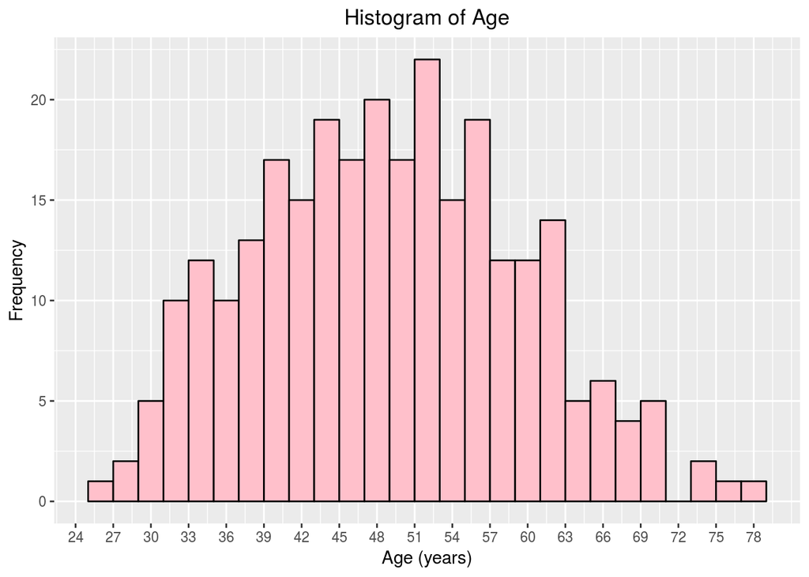

```r
# Create a histogram
ggplot(d, aes(x=age)) +
    geom_histogram(binwidth=2, colour="black", fill="pink") + ggtitle("Distribution of Age") + xlab("Age (years)") +  ylab("Frequency") +   ggtitle("Histogram of Age") +
  theme(plot.title = element_text(hjust = 0.5)) + scale_x_continuous(breaks = seq(0, 80, by = 3))
```

```r
summary(d$age)
```

```
##    Min. 1st Qu.  Median    Mean 3rd Qu.    Max.
##   26.00   41.00   49.00   49.32   56.00   78.00
```

## Correlation Matrix

We can look at the association between the covariates. The matrix below was calculated using the pearson correlation coefficient which measures the linear dependence between two variables. The matrix below also has information regarding the signficance level ($\alpha = 0.01$) of the perarson correlation coefficent.

### Insights

1. `ascites` and `edema` have a PCC of 0.63476307. It makes sense that these variables are positively correlated: they are both symptoms of liver disease.
2. `bili` and `futime` have a PCC of -0.43025241. It makes sense that these variables are negatively correlated: elevated levels of bilirubin are a sign of liver damage or disease – it indicates that the liver isn’t clearing bilirubin properly.
3. `stage` and `hepato` have a PCC of 0.47913224. It makes sense that these variables are positively correlated. Hepatomegaly is an abnormal enlargement of the liver. An enlarged liver is indicates that the disease has progress to an advanced histologic stage.

The rest of the variables are not as strongly correlated. A stepwise regression of each covariate will help us better explain the data.

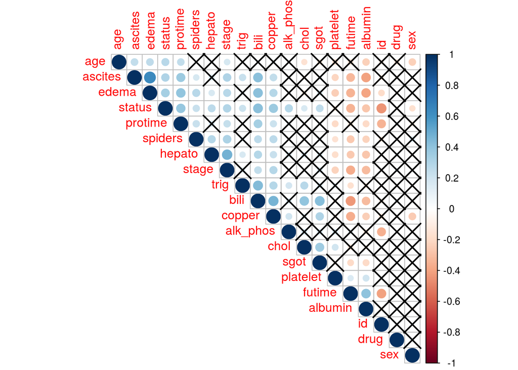

```r
cor.mtest <- function(mat) {
    mat <- as.matrix(mat)
    n <- ncol(mat)
    p.mat<- matrix(NA, n, n)
    diag(p.mat) <- 0
    for (i in 1:(n - 1)) {
        for (j in (i + 1):n) {
            tmp <- cor.test(mat[, i], mat[, j])
            p.mat[i, j] <- p.mat[j, i] <- tmp$p.value
        }
    }
  colnames(p.mat) <- rownames(p.mat) <- colnames(mat)
  p.mat
}

# matrix of correlation statistic
corr<-cor(d)

# matrix of the p-value of the correlation
p.mat <- cor.mtest(d)

#corrplot(corr, method = "circle")

# Specialized the insignificant value according to the significant level
corrplot(corr, type="upper", order="hclust",
         p.mat = p.mat, sig.level = 0.01)  # 0.01 is more stringent than 0.05.
```

```r
# small p-value reject null hypothesis.
```

## Density Distribution of Quantitative Varibles

Lastly, we can look at the distribution of the quantitative variables. The code used to generate these plots are available on the [Github repository](https://github.com/smoijueh/PBC-ClinicalStudy/).

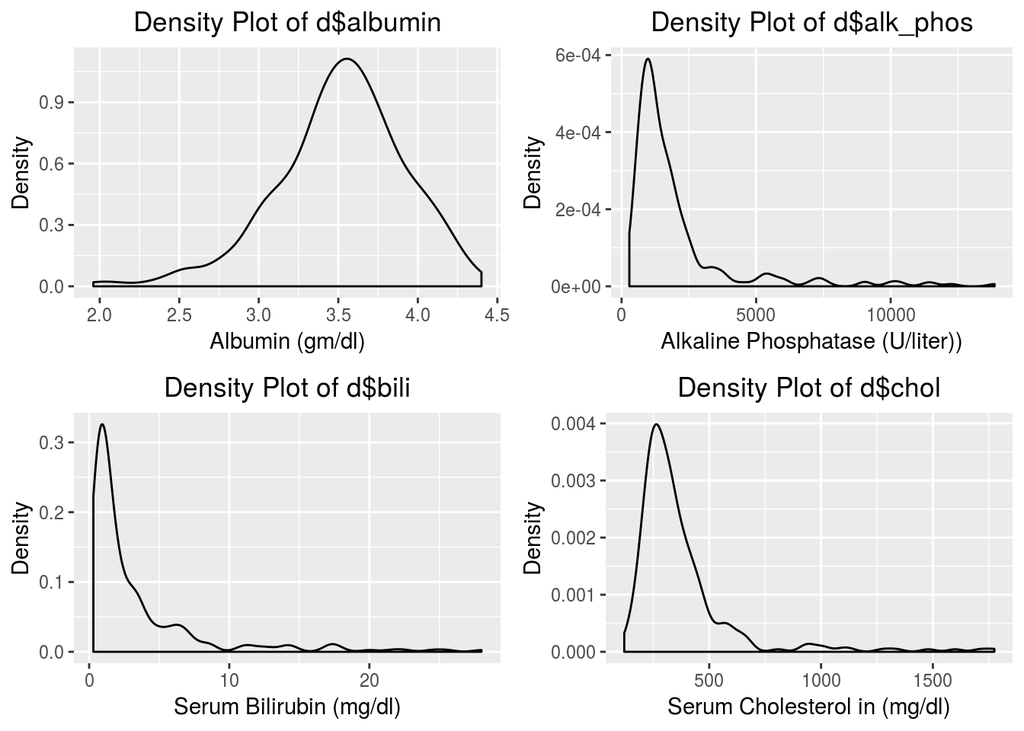

```r
# Arrange and display the plots into a 2x4 grid. xlab(paste0("log( d$", x,")"))
grid.arrange(density_plot(l[1]),
             density_plot(l[2]),
             density_plot(l[3]),
             density_plot(l[4]), ncol=2)
```

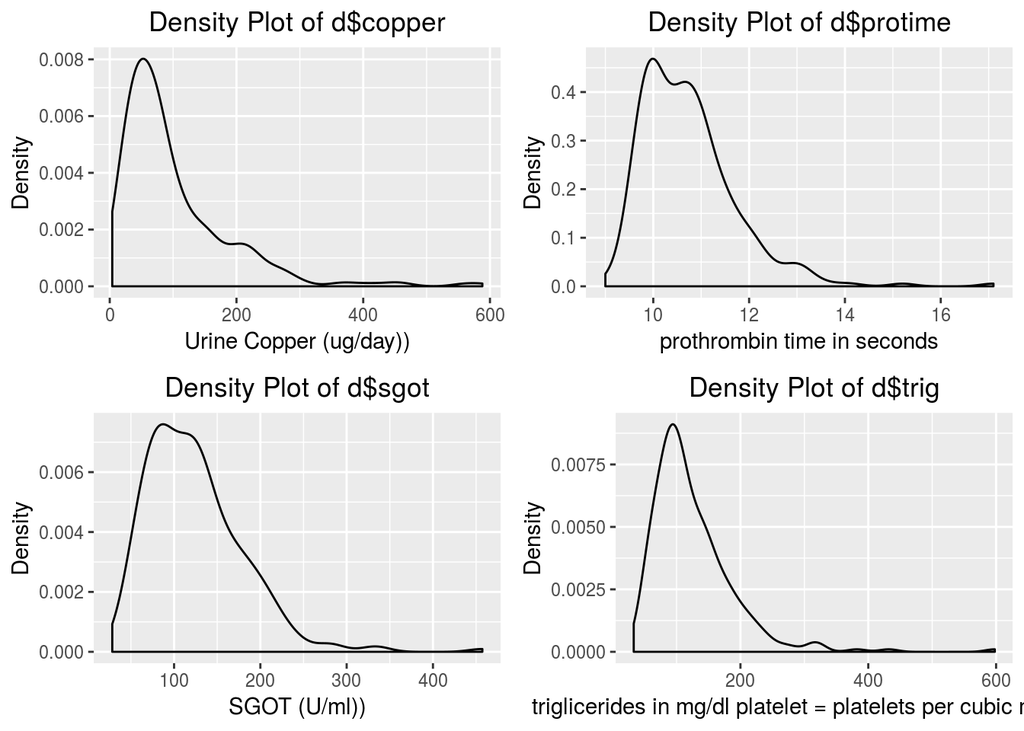

```r
# Arrange and display the plots into a 2x4 grid
grid.arrange(density_plot(l[5]),
             density_plot(l[6]),
             density_plot(l[7]),
             density_plot(l[8]), ncol=2)
```

We can apply a log transformation to make the data more normally distributed. This will help later when we model the data.

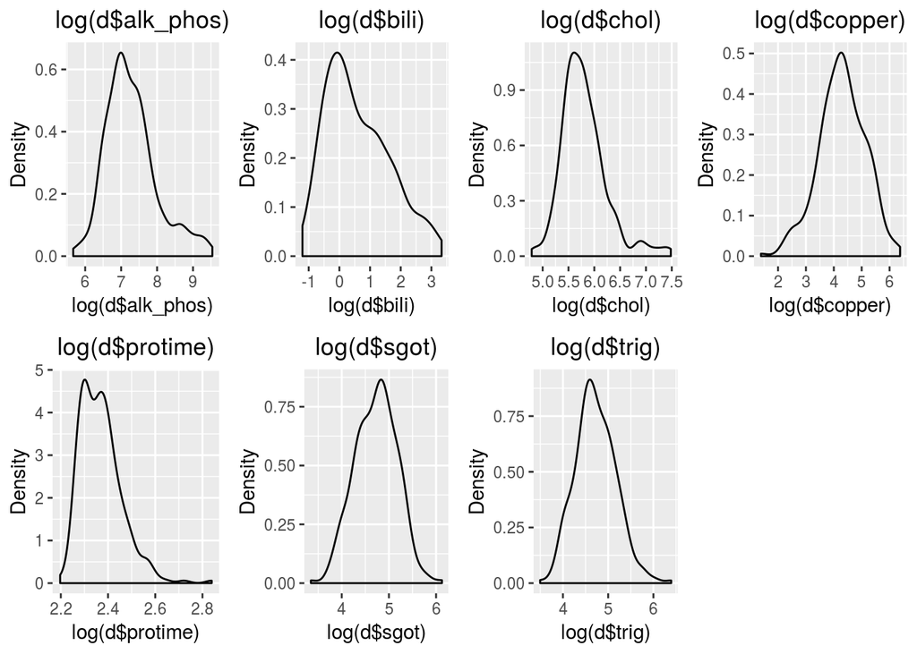

```r
# apply log transformation on left skewed data
# Arrange and display the plots into a 2x1 grid
grid.arrange(density_plot(l[2], 1),
             density_plot(l[3], 1),
             density_plot(l[4], 1),
             density_plot(l[5], 1),
             density_plot(l[6], 1),
             density_plot(l[7], 1),
             density_plot(l[8], 1), ncol=4)
```

# Transform the Data

We saw in the previous section that we have to apply a log transformation to certain covariates. These variables will be used later when we create a Cox Proportional-Hazards Regression Model.

```r
# apply log transformation -- 7 variables
d$alk_phos <- log(d$alk_phos)
d$bili <- log(d$bili)
d$chol <- log(d$chol)
d$copper <- log(d$copper)
d$protime <- log(d$protime)
d$sgot <- log(d$sgot)
d$trig <- log(d$trig)

# change data labels -- 7 variables
d$drug <- factor(d$drug,
                     levels = c("1", "2"),
                     labels = c("D-penicillamine", "placebo"))

d$sex <- factor(d$sex,
                     levels = c("0", "1"),
                     labels = c("male", "female"))

d$ascites <- factor(d$ascites,
                    levels = c("0", "1"),
                    labels = c("no", "yes"))

d$hepato <- factor(d$hepato,
                    levels = c("0", "1"),
                    labels = c("no", "yes"))

d$spiders <- factor(d$spider,
                    levels = c("0", "1"),
                    labels = c("no", "yes"))

d$edema <- factor(d$edema,
                    levels = c("0", "0.5", "1"),
                    labels = c("no edema and no diuretic therapy for edema",
                               "edema present without diuretics, or edema resolved by diuretics",
                               "edema despite diuretic therapy"))

d$stage <- factor(d$stage,
                      levels = c("1", "2", "3", "4"),
                      labels = c("one", "two", "three", "four"))
```

# Survival Analysis

In this section we will investigate whether there is a difference in survival between the two groups of patients. We will do this by generating survival curves for each group and performing a log-rank comparison. This will enable us to make a conclusion regarding the efficacy of D-pencillamine (the experimental drug) on the sample population.

Click on the tabs for different aspects of the Survival Analysis.

## Null and Alternative Hypothesis

[figure not shown]

### Null and Alternative Hypothesis

$H_o : S_1(t) = S_2(t), \forall t$

$H_a : \exists t : S_1(t) \neq S_2(t)$

The hypotheses above are as follows

$H_o:$ There is no significant difference in survival between patients who receive D-penicillamine and patients who receive the placebo.

$H_a:$ There is a significant difference in survival between patients who receive D-penicillamine and patients who receive the placebo.

We will consider `p < 0.05` to indicate statistical significance. We will perform a [Log-Rank test](https://en.wikipedia.org/wiki/Logrank_test) to compare the survival distributions of the two treatment groups in the clincal trial.

Click on the next tab for the Survival Analysis.

## Estimating Survival: Life Table

### Creating the Survival Object

First we create a survival object. After which we can view the survival times of the events. The event is interest is death. A plus indicates censored data. The duration of the survival times below are **number of days**.

```r
# create the survival object. the event is denoted by 1
fusurv <- Surv(d$futime, d$status)

fusurv
```

```
##   [1]  400  4500+ 1012  1925  1504+ 1832+ 2466  2400    51  3762   304
##  [12] 3577+ 3584  3672+  769   131  4232+ 1356  3445+  673   264  4079
##  [23] 4127+ 1444    77   549  4509+  321  3839  4523+ 3170  3933+ 2847
##  [34] 3611+  223  3244  2297  4556+ 3428  2256  2576+ 4427+ 2598  3853
##  [45] 2386  1434  1360  1847  3282  2224  4365+ 4256+ 3090   859  1487
##  [56] 3992+ 4191  2769  4039+ 1170  4196+ 4184+ 4190+ 1827  1191    71
##  [67]  326  1690  3707+  890  2540  3574  4050+ 4032+ 3358  1657   198
##  [78] 2452+ 1741  2689   460   388  3913+  750   611  3823+ 3820+  552
##  [89] 3581+ 3099+  110  3086  3092+ 3388+ 2583  2504+ 2105  2350+ 3445
## [100]  980  3395  3422+ 3336+ 1083  2288   515  2033+  191  3297+ 3069+
## [111] 2468+ 3255+ 1413   850  2944+ 2796  3149+ 3150+ 3098+ 2990+ 1297
## [122] 2106+ 3059+ 3050+ 2419   786   943  2976+ 2995+ 1427   762  2870+
## [133] 1152  2863+  140  2666+  853  2835+ 2475+ 1536  2772+ 2797+  186
## [144] 2055  1077  2721+ 1682  1212  2692+ 2301+ 2657+ 2624+ 2609+ 2573+
## [155] 2563+ 2556+ 2241+  974  2527+ 1576   733  2332+ 2456+  216  2443+
## [166]  797  2449+ 2330+ 2363+ 2365+ 2357+ 1592+ 2318+ 2294+ 2272+ 2221+
## [177] 2090  2255+  904  2216+ 2224+ 2176+ 2178+ 1786  1080   790  2157+
## [188] 1235  2050+  597   334  1945+ 2022+ 1978+  999  1967+  348  1979+
## [199] 1165  1951+ 1932+ 1776+ 1882+ 1908+ 1882+  694  1831+  837+ 1810+
## [210]  930  1690  1790+ 1435+  732+ 1785+ 1783+ 1769+ 1457+ 1770+ 1765+
## [221]  737+ 1735+ 1701+ 1614+ 1702+ 1615+ 1656+ 1666+ 1301+ 1542+ 1084+
## [232] 1614+  179  1191  1363+ 1568+ 1569+ 1525+ 1558+ 1349+ 1481+ 1434+
## [243] 1420+ 1433+ 1412+   41  1455+ 1030+ 1418+ 1401+ 1408+ 1234+ 1067+
## [254]  799  1363+  901+ 1329+ 1320+ 1302+  877+ 1321+  533+ 1300+ 1293+
## [265] 1295+ 1271+ 1250+ 1230+ 1216+ 1216+ 1149+ 1153+  994+  939+  839+
## [276]  788+
```

### Fitting the Kaplan-Meier Estimate

Here we stratify the curve depending on what **drug treatment** the patient received.

```r
# fit the Kaplan-Meier estimator for drug
fit_KM = survfit(fusurv ~ drug, type="kaplan-meier", data = d)
```

### Life Table

A `summary()` of the resulting `fit_KM` object shows, among others things, the survival times, the proportion of surviving patients at every time point, the treatment groups, and the confidence intervals.

The `summary()` of the `fit_KM` objects produced something called a Life Table. It shows, for certain durations, what the probability is that a person at that time point will die. In other words, it represents the survivorship of the PBC patients.

```r
summary(fit_KM)
```

```
## Call: survfit(formula = fusurv ~ drug, data = d, type = "kaplan-meier")
##
##                 drug=D-penicillamine
##  time n.risk n.event survival std.err lower 95% CI upper 95% CI
##    41    136       1    0.993 0.00733        0.978        1.000
##    71    135       1    0.985 0.01032        0.965        1.000
##   131    134       1    0.978 0.01259        0.954        1.000
##   140    133       1    0.971 0.01449        0.943        0.999
##   179    132       1    0.963 0.01614        0.932        0.995
##   198    131       1    0.956 0.01761        0.922        0.991
##   223    130       1    0.949 0.01895        0.912        0.986
##   334    129       1    0.941 0.02018        0.902        0.982
##   348    128       1    0.934 0.02132        0.893        0.977
##   388    127       1    0.926 0.02238        0.884        0.971
##   400    126       1    0.919 0.02338        0.874        0.966
```

[output cut: 101 more lines]

#### How to Interpret the Life Table

- The `time` column tells us when the event of interest occurred. In this case, it shows the time point (in days) one or more patients died.
- The `n.risk` column contains the number of PBC patients that are still alive at a given time.
- The `n.event` column contains the number of PBC patients that died at a given time.
- `Survival` is the probability of survival for PBC patients left in the study.

## Kaplan-Meier Survival Curve and Log-Rank Hypothesis Test

We can examine the corresponding survival curve. The plot below shows the probability that a patient is alive at time `t` given they took the experimental drug or the placebo.

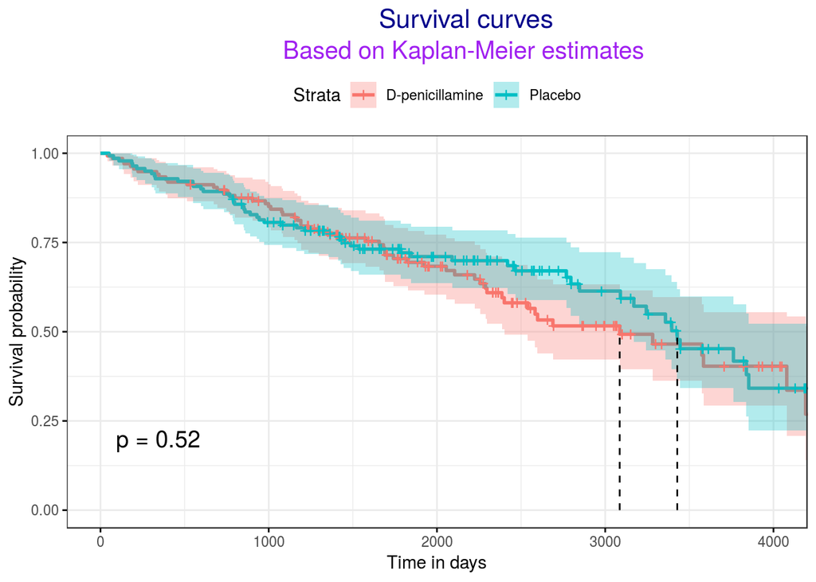

```r
ggsurv<-ggsurvplot(fit_KM, data=d,
                   pval = TRUE,
                   conf.int = TRUE,
                   ggtheme = theme_bw(),
                   surv.median.line = "v",
                   legend.labs = c("D-penicillamine", "Placebo"),
                   title = "Survival curves",
                   subtitle = "Based on Kaplan-Meier estimates",
                   xlab = "Time in days")
                   #palette = c("#E7B800", "#2E9FDF")) # custom color palettes.)

# Labels for Survival Curves (plot)
ggsurv$plot <- ggsurv$plot + labs(
  title    = "\tSurvival curves",
  subtitle = "\tBased on Kaplan-Meier estimates",
  caption = NULL
  ) + theme(plot.title = element_text(hjust = 0.5)) + theme(plot.subtitle = element_text(hjust = 0.5))

ggsurv <- ggpar(
  ggsurv,
  font.title    = c(16,"darkblue"),
  font.subtitle = c(15, "purple")
)

ggsurv
```

### Interpreting the Kaplan-Meier Survival Curve

The Kaplan-Meier estimate is a step function, where there is a step down each time an event occurs. Each horizontal line represents the probability that a patient is still alive after a given time `t`. The vertical lines indicate a censored event that occurred at time `t`.

The Kaplan-Meier plots stratified by treatment group shows that the survival times are quite similar for some time into the study. The curves begin to slightly diverge around the $2000$ day mark but converge again around the $3400$ day mark. Furthermore, the 95% confidence intervals of the curve overlap for a significant duration of the observation time.

The median survival time is the time at which 50% of the patient population have died and 50% have survived. This statistic is indicated by the veritical tick marks to the x-axis.

Patient treated with the D-penicillamine drug had a median survival time of `3086` days. Patients treated with the placebo have a greater probability of survival than those treated with the experimental drug – the median survival time for the placebo was `3428` days.

```r
summary(fit_KM)$table
```

```
##                      records n.max n.start events   *rmean *se(rmean)
## drug=D-penicillamine     136   136     136     57 2875.988   152.5324
## drug=placebo             140   140     140     54 3008.685   150.0502
##                      median 0.95LCL 0.95UCL
## drug=D-penicillamine   3086    2400      NA
## drug=placebo           3428    3090      NA
```

These results suggest that **D-pencillamine** is an **ineffective** drug for treating PBC.

We can quantify this with a statistical hypothesis test.

### Log-Rank Hypothesis Test

The **log-rank p-value of 0.52** indicates a **non-significant** result $(\alpha = 0.05)$. Neither of the treatments are significantly superior.

In other words:

We fail to reject the null hypothesis. There is **no significant difference** in survival between the patients who receive D-penicillamine and patient who receive the placebo.

## Estimating $x$-year survival

A quantity often of interest in survival analysis is the probability of surviving a certain number $x$ of years.

### Calculating Survival Time using the `survival` package

```r
# 2256 days is about 6 years and four months
summary(fit_KM, times = 2256)
```

```
## Call: survfit(formula = fusurv ~ drug, data = d, type = "kaplan-meier")
##
##                 drug=D-penicillamine
##         time       n.risk      n.event     survival      std.err
##     2.26e+03     5.20e+01     4.30e+01     6.35e-01     4.62e-02
## lower 95% CI upper 95% CI
##     5.50e-01     7.32e-01
##
##                 drug=placebo
##         time       n.risk      n.event     survival      std.err
##     2.26e+03     5.40e+01     3.90e+01     6.99e-01     4.12e-02
## lower 95% CI upper 95% CI
##     6.23e-01     7.85e-01
```

- PBC patients treated with D-pencicillamine have a $63.5\%$ probability of surviving to $2256$ days.
- PBC patients treated with the placebo have a $69.9\%$ probability of surviving to $2256$ years.

### Calculating Survival Time by Hand

Since we have access to the survival table, we can calculate this survival probability by “by hand.”

```r
summary(fit_KM, censored = TRUE)
```

```
## Call: survfit(formula = fusurv ~ drug, data = d, type = "kaplan-meier")
##
##                 drug=D-penicillamine
##  time n.risk n.event survival std.err lower 95% CI upper 95% CI
##    41    136       1    0.993 0.00733        0.978        1.000
##    71    135       1    0.985 0.01032        0.965        1.000
##   131    134       1    0.978 0.01259        0.954        1.000
##   140    133       1    0.971 0.01449        0.943        0.999
##   179    132       1    0.963 0.01614        0.932        0.995
##   198    131       1    0.956 0.01761        0.922        0.991
##   223    130       1    0.949 0.01895        0.912        0.986
##   334    129       1    0.941 0.02018        0.902        0.982
##   348    128       1    0.934 0.02132        0.893        0.977
##   388    127       1    0.926 0.02238        0.884        0.971
##   400    126       1    0.919 0.02338        0.874        0.966
```

[output cut: 263 more lines]

The definition of the Kaplan-Meier Estimate is:

$\hat S(t) = \underset{t_i < t} \Pi\frac{n_i-d_i}{n_i}$

where $d_i$ are the number of death events at time $t$ and $n_i$ is the number of patients at risk of death just prior to time $t$.

What the above essentially tells us is that the value of the survival function for time $t$, is the product of the survival probabilities for all individual time periods leading up to time $t$.

We can define the survival probability for an individual time period as follows:

$S_0 = \frac{\text{No. of Patients at Risk at $t_i$} -\text{No. of Patients who Died at $t_i$}}{\text{No. of Patients at Risk at $t_i$}}$

Let’s walk through a simple example and calculate the probability that a PBC patient treated with D-pencicillamine survives longer than 2256 days. First we calculate the individual survival probabilities for $t = 2254$, $t = 2255$, and $t = 2256$.

First we calculate the individual survival probability for time $t = 2254$:

```r
summary(fit_KM, times = 2254)
```

```
## Call: survfit(formula = fusurv ~ drug, data = d, type = "kaplan-meier")
##
##                 drug=D-penicillamine
##         time       n.risk      n.event     survival      std.err
##     2.25e+03     5.30e+01     4.20e+01     6.47e-01     4.54e-02
## lower 95% CI upper 95% CI
##     5.64e-01     7.42e-01
##
##                 drug=placebo
##         time       n.risk      n.event     survival      std.err
##     2.25e+03     5.40e+01     3.90e+01     6.99e-01     4.12e-02
## lower 95% CI upper 95% CI
##     6.23e-01     7.85e-01
```

The individual suvival probability for time $t = 2254$ is $64.7\%$.

Next we calculate the individual survival probability for time $t = 2255$:

$S_{2255} = \frac{\text{No. of Patients at Risk at $t_{2255}$} -\text{No. of Patients who Died at $t_{2255}$}}{\text{No. of Patients at Risk at $t_{2255}$}} = \frac{53 - 0}{53} = \frac{53}{53} = 1.0000000$

A censored event occurred at time $t=2254$ and nobody died so the individual survival probability is $1$.

Lastly, we calculate the individual survival probability for time $t=2256$:

$S_{2256} = \frac{\text{No. of Patients at Risk at $t_{2256}$} -\text{No. of Patients who Died at $t_{2256}$}}{\text{No. of Patients at Risk at $t_{2256}$}} = \frac{52 - 1}{52} = \frac{51}{52} = 0.9807692$

The calculate the final probability of survival at time $t_{2256}$:

$S(2256) = S_{2254} \times S_{2255} \times S_{2256} = 0.647 \times \frac{53}{53} \times \frac{51}{52} = 0.6345577$

This probability is approximately equal to the probability we calculated above (0.635).

# Cox Proportional-Hazards Model

Click on the tabs for different aspects of the Cox Regression Analysis.

## The Basics

The **Cox Proportional-Hazards Model** is a multivariate regression model used to investigate the association between the survival time of patients and the simultaneous effect of one or more predictor variables.

The Cox model is expressed by the hazard function denoted by $h(t)$. The hazard function can be interpreted as the risk of dying at time t. It can be estimated as follow:

$h(t) = h_0(t) \times exp(\beta_1x_1 + \beta_2x_2 + \ldots + \beta_px_p)$

where,

- $t$ represents the survival time
- $h(t)$ is the hazard function determined by a set of p covariates $(x_1,x_2,\ldots,x_p)$
- the coefficients $(\beta_1, \beta_2,\ldots, \beta_p)$ measure the impact (i.e., the effect size) of the covariates
- the term $h_0$ is called the baseline hazard.
  - It corresponds to the value of the hazard if all the $x_i$ are equal to zero (the quantity $exp(0)$ equals 1).
  - The ‘t’ in h(t) reminds us that the hazard may vary over time.

In the final part of the analysis, we will use the Cox Regression Model to quantify the effect size that each clinical characteristic has on a patient’s survival.

Before doing so, we have to check the following key assumptions of the Cox model:

- Proportional-Hazards model assumption: the hazard curves for the groups of observations (or patients) should be proportional and cannot cross.
- Non-linearity in the relationship between the log hazard and the covariates
- Non-informative censoring: The distribution of survival times (T) provides no information about the distribution of censorship times (C), and vice versa.

We test these assumptions in the next section.

## Cox Model Assumptions

In this section we evaluate the Cox model assumptions:

- Proportional-Hazards Model assumption
- Non-linearity
- Non-informative censoring

Note that, when used inappropriately, statistical models may give rise to misleading conclusions.  
Therefore, it’s important to check that a given model is an appropriate representation of the data.

### Testing the Proportional-Hazards Assumption

The proportional hazards assumption can be checked based on the scaled *Schoenfeld residuals*.

The proportional hazards assumption is supported by a non-significant relationship between the *Schoenfeld residuals* and time. The two must be independent.

To test this assumption, we can run the`cox.zph` function:

```r
res.cox <- coxph(fusurv ~ drug + age + sex + ascites + hepato +
                   spiders + edema + bili + chol + albumin + copper + alk_phos +
                   sgot + trig + protime + stage , data = d)

test.ph <- cox.zph(res.cox)
test.ph
```

```
##                                                                           rho
## drugplacebo                                                          -0.06319
## age                                                                  -0.02724
## sexfemale                                                            -0.04108
## ascitesyes                                                           -0.03003
## hepatoyes                                                             0.09112
## spidersyes                                                            0.08523
## edemaedema present without diuretics, or edema resolved by diuretics -0.18557
## edemaedema despite diuretic therapy                                  -0.04507
## bili                                                                  0.04110
## chol                                                                  0.05735
## albumin                                                              -0.04425
## copper                                                               -0.09826
## alk_phos                                                              0.03034
## sgot                                                                 -0.04760
## trig                                                                  0.05902
## protime                                                              -0.06181
## stagetwo                                                             -0.00915
## stagethree                                                           -0.02210
## stagefour                                                            -0.04841
## GLOBAL                                                                     NA
##                                                                         chisq
## drugplacebo                                                           0.56195
## age                                                                   0.08131
## sexfemale                                                             0.22696
## ascitesyes                                                            0.12244
## hepatoyes                                                             1.10530
## spidersyes                                                            1.06761
## edemaedema present without diuretics, or edema resolved by diuretics  4.73468
## edemaedema despite diuretic therapy                                   0.27923
## bili                                                                  0.24187
## chol                                                                  0.43565
## albumin                                                               0.30232
## copper                                                                1.27903
## alk_phos                                                              0.10824
## sgot                                                                  0.27233
## trig                                                                  0.43565
## protime                                                               0.53061
## stagetwo                                                              0.00942
## stagethree                                                            0.05351
```

[output cut: 8 more lines]

```
## spidersyes                                                           0.3015
## edemaedema present without diuretics, or edema resolved by diuretics 0.0296
## edemaedema despite diuretic therapy                                  0.5972
## bili                                                                 0.6229
## chol                                                                 0.5092
## albumin                                                              0.5824
## copper                                                               0.2581
## alk_phos                                                             0.7422
## sgot                                                                 0.6018
## trig                                                                 0.5092
## protime                                                              0.4663
## stagetwo                                                             0.9227
## stagethree                                                           0.8171
## stagefour                                                            0.6190
## GLOBAL                                                               0.6248
```

### Testing the Non Linearity Assumption

The Cox Model assumes that continuous covariates have a nonlinear form. We can test the nonlinearity assumption by plotting the *Martingale residuals* against the continuous covariates.

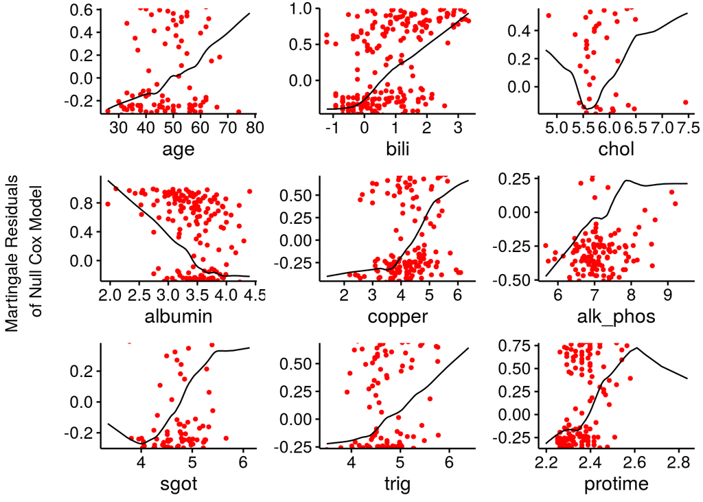

```r
ggcoxfunctional(fusurv ~ age + bili + chol + albumin + copper +
                  alk_phos + sgot + trig + protime, data = d)
```

## Cox Proportional-Hazards Model

We can build a Cox-Proportional Hazard Model using the `coxph` function.

```r
# Fit a Cox proportional-hazards model
res.cox <- coxph(fusurv ~ drug + age + sex + ascites + hepato +
                   spiders + edema + bili + chol + albumin + copper + alk_phos +
                   sgot + trig + protime + stage , data = d)
```

Typing `res.cox` returns the full results of the regression analysis.

We can see a tidy version of the results using the `tidy` function:

```r
broom::tidy(res.cox)
```

```
## # A tibble: 19 x 7
##    term            estimate std.error statistic p.value conf.low conf.high
##    <chr>              <dbl>     <dbl>     <dbl>   <dbl>    <dbl>     <dbl>
##  1 drugplacebo      -0.0476    0.218     -0.219 8.27e-1 -0.475     0.379
##  2 age               0.0291    0.0113     2.56  1.04e-2  0.00684   0.0513
##  3 sexfemale        -0.169     0.309     -0.546 5.85e-1 -0.774     0.437
##  4 ascitesyes        0.138     0.383      0.361 7.18e-1 -0.613     0.890
##  5 hepatoyes        -0.107     0.257     -0.419 6.75e-1 -0.610     0.396
##  6 spidersyes        0.0290    0.242      0.120 9.05e-1 -0.445     0.503
##  7 edemaedema pre…   0.289     0.323      0.895 3.71e-1 -0.344     0.922
##  8 edemaedema des…   0.978     0.403      2.43  1.51e-2  0.189     1.77
##  9 bili              0.623     0.181      3.44  5.82e-4  0.268     0.978
## 10 chol              0.197     0.288      0.684 4.94e-1 -0.367     0.761
## 11 albumin          -0.603     0.304     -1.98  4.76e-2 -1.20     -0.00645
## 12 copper            0.298     0.180      1.65  9.81e-2 -0.0550    0.650
## 13 alk_phos          0.0528    0.145      0.364 7.16e-1 -0.232     0.337
## 14 sgot              0.330     0.298      1.11  2.67e-1 -0.253     0.914
## 15 trig             -0.0806    0.262     -0.308 7.58e-1 -0.594     0.433
## 16 protime           2.78      1.41       1.97  4.89e-2  0.0137    5.55
## 17 stagetwo          1.15      1.05       1.09  2.77e-1 -0.921     3.21
## 18 stagethree        1.32      1.04       1.27  2.03e-1 -0.711     3.35
## 19 stagefour         1.73      1.06       1.63  1.03e-1 -0.346     3.80
```

### Hazard Ratios

Recall that the Cox model is expressed by the hazard function $h(t)$:

$h(t) = h_0(t) \times exp(\beta_1x_1 + \beta_2x_2 + \ldots + \beta_px_p)$

The quantity of interest from a Cox regression model is the hazard ratio. The quantities $exp(\beta_i)$ are the hazard ratios.

The Hazard Ratio (HR) can be interpreted as follows:

- HR = 1: No effect
- HR < 1: indicates a decreased risk of death
- HR > 1: indicates an increased risk of death

### How to Interpret Results

The `estimate` column in the summary above is the regression parameter $\beta_i$ of the Cox model.

The `estimate` column quantifies the effect size (the impact) that the covariate has on the patient’s survival time.

So for example, we obtained a regression parameter $\beta_1 = -0.0476$ for the placebo vs D-penicillamine (the experiemental drug). The hazard ratio for this covariate is $HR = exp(\beta_1) = 0.95348$.

A HR < 1 indicates reduced hazard of death.

Therefore, we would say that PBC patients treated with the placebo have a 0.95348 times **reduced** hazard of death compared to PBC patients treated with D-penicillamine. The p-value associated with this regression parameter is $p=0.826919$, which indicates that the difference is not significant.

This supports the result we obtained from the Kaplan-Meier Survival Analysis. Patients treated with the placebo have a slightly higher survival time but the difference is not significantly greater than patients treated with D-penicillamine.

As a final point, the `statistic` column of the result above is the z-score. `conf.low` and `conf.high` are the low and high 95% confidence intervals, respectively.

The rest of the covariates can be analyzed in a similar fashion.

## Visualizing the Hazard Ratios via Forest Plot

We can visualize the hazard ratios for all of the covariates using the `ggforest` function. The following visual is called a [Forest Plot](https://en.wikipedia.org/wiki/Forest_plot).

Zoom In to see the text more clearly.

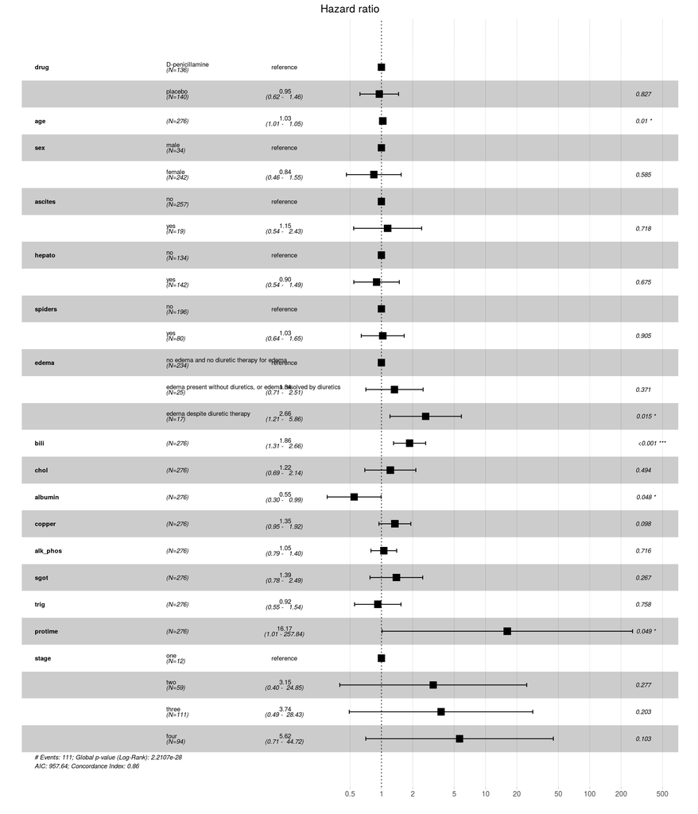

```r
ggforest(res.cox, data = d)
```

### How to Interpret

- The numbers of the far right of the plot are the p-values associated with the regression analysis. The p-values indicate whether or not the covariate’s impact on the patient’s survival time is statistically significant.
  - Statistically significant covariates are indicated by a “*" next to the p-value.
- The numbers in the third column are the Hazard Ratios (HR).
- The numbers below in the parenthesis are the 95% confidence interval.
- The numbers along the x-axis are the effect size.
- The AIC (Akaike information criterion) of the model is 957.64.

### Sample Analysis

The covariate `protime` has the largest impact (effect size) on a patient’s survival. A hazard ratio of 16.17 indicates that in patients with who have a prothrombin time that deviates from the average of 10 to 14 seconds have an increased risk of death than patients who have a normal prothrombin time.

As shown by the forest plot, the respective 95% confidence interval is 1.01 - 257.84 and this result is significant (p-val = 0.049).

#### Medical Interpretation

- Prothrombin time is the time it takes for blood to clot.
- Bleeding within the body activates a complex system of plasma proteins, called **coagulation** factors, which promote blood clot formation.
- The liver is responsible for producing most of these **coagulation** factors.
- If the blood clots too quickly or too slowly during bleeding (uncontrolled bleeding), this is a sign that the liver is not functioning properly.
  - Either the clotting factors are not being produced or vitamin K is not being absorbed.

### Summary of Results

Using this model, we see that the covariates `age`, `edema`, `bili`, `albumin`, and `protime` significantly influence the patient’s risk of death in this study. The effect sizes are shown in the Forest Plot above.

# Conclusion

In this notebook, we performed a **Survival Analysis** and built a multivariate **Cox Proportional-Hazards Model** to evaluate the results of the clinical study.

We found that:

1. There is no statistically significant difference in survival between PBC patients treated with D-penicillamine (the experimental drug) and PBC patients treated with the placebo.
2. The covariates `age`, `edema`, `bili`, `albumin`, and `protime` significantly influence the patient’s risk of death in this study. The effect sizes of these clinical characteristics are shown in the Forest Plot of the previous section above.
3. D-penicillamine was ineffective for treating the PBC patients in this study.

Thanks for reading.

$\blacksquare$